# Ford GoBike System Data

## by Fatma ElBoshy

## Investigation Overview

> The overall goals of my investigation is to answer the following questions:
> 1. What's the common age range?
> 2. How long does the average trip take?
> 3. What is the percentage of each gender participating?
> 4. What is the age range for each gender group?
> 5. Finally, what is the distance crossed for each age group?

## Dataset Overview

> This data set includes information about individual rides made in a bike-sharing system covering the greater San Francisco Bay area.

> My dataset is 183412 rows and 17 column, after cleaning it became 174952 rows and 14 column

> The main features I'm interested in are 'distatnce' as our dependent variable. I will extract it from the start coorinates and end coordinates.

> 'user_type', 'member_birth_year', 'member_gender' as well as 'duration_sec' as our independent variables.

## Univariate Exploration

## Age Distribution

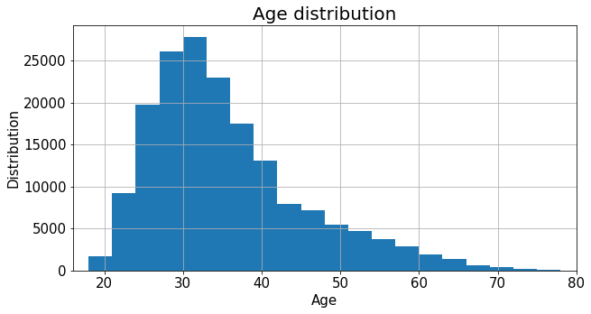

## How long does a trip usually take?

> duration-wise and distance-wise

## Duration distribution

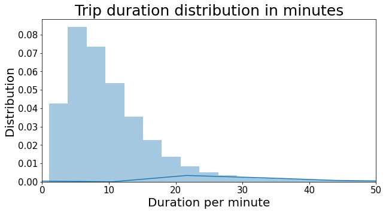

## Distance Distribution

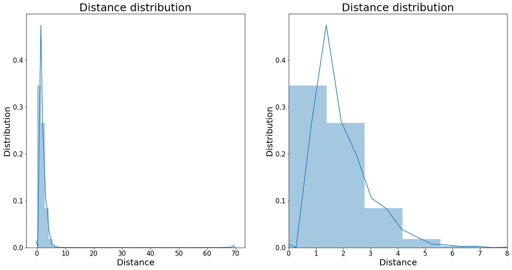

#### The distance distribution is a little skewed, but we can conclude that people tend to go for short trips, usually between 100 m and 2.5 km max.

## Bivariate Exploration

## Gender vs User type

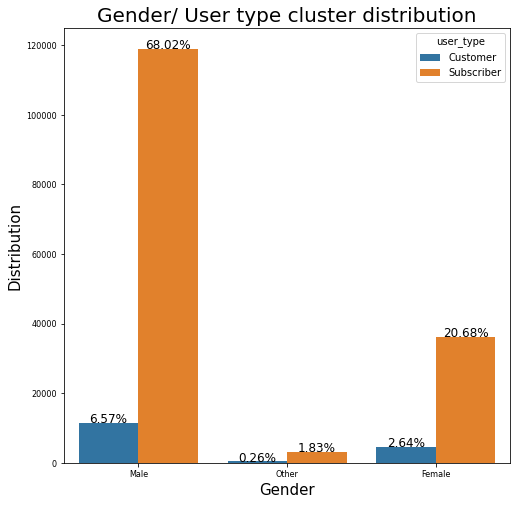

#### As we observe, Subscribers make up pretty much most of each gender group.

## Gender vs Age

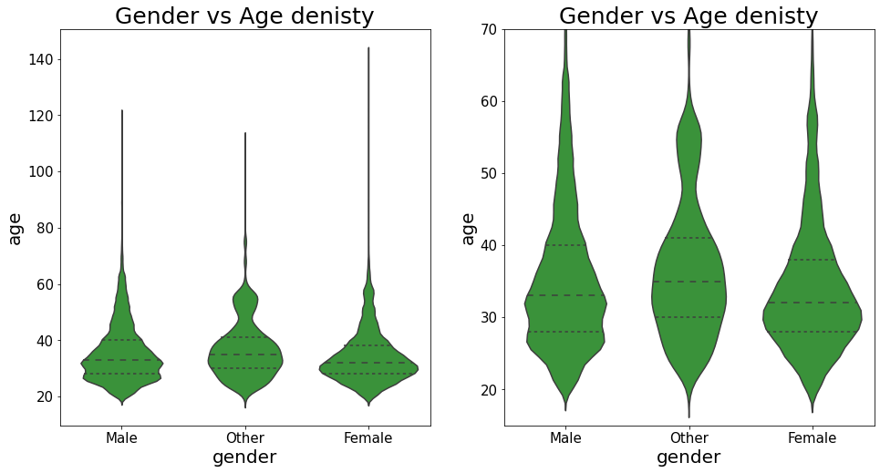

#### At older ages,between age 50 and 60, 'others' gender tend to ride bikes more than either males or females peers. But above 30s 'males' tend to ride bikes more while females around 30 years old tend to ride bikes more than the other 2 groups

## Age vs Distance

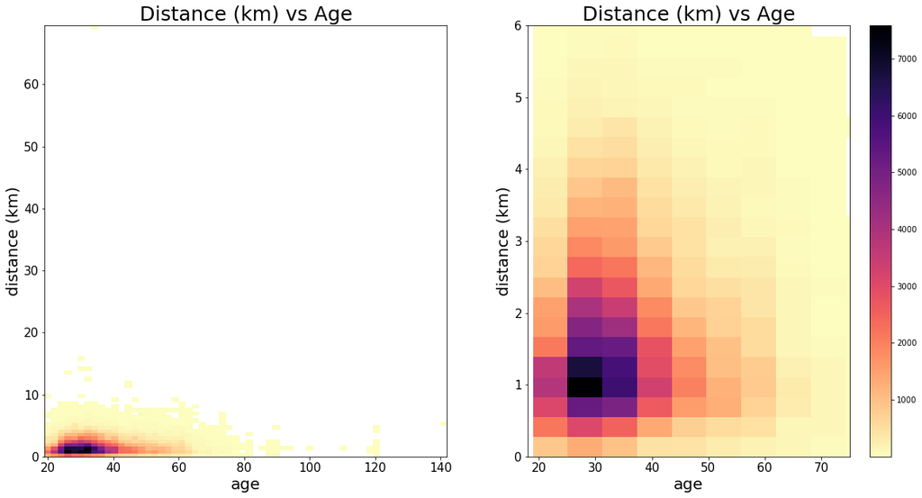

#### We see here in more details that young people (age 25 to 35) tend to go for distances between 0.5 km to around 2 km.

## Multivariate Exploration

## Distance vs Duration per gender

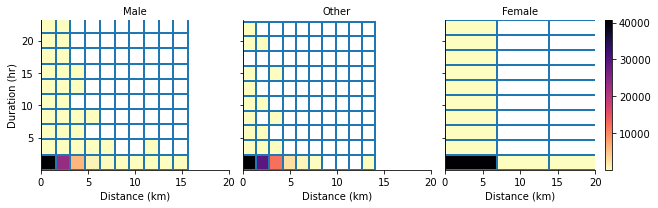